# IODS course project

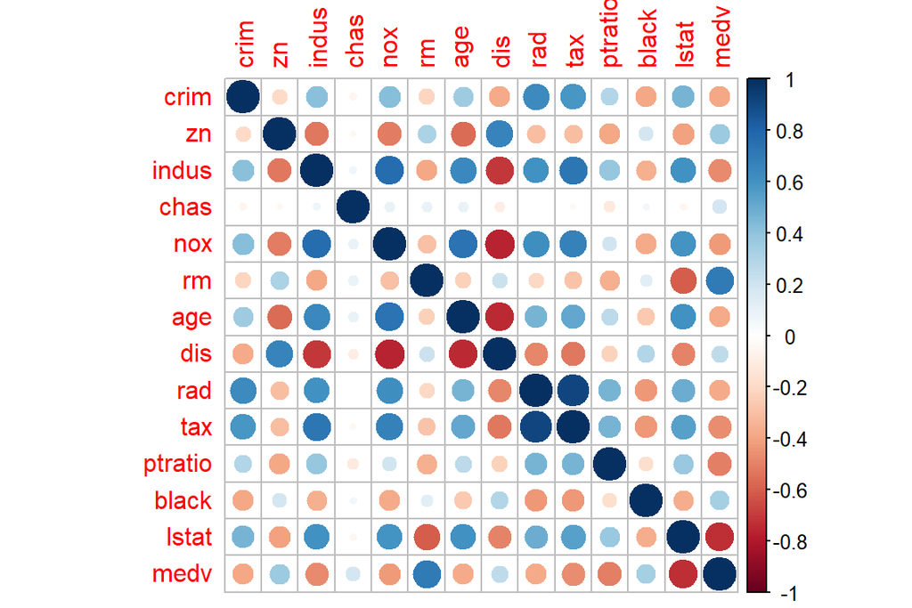

```r
corrplot(cor_matrix, method="circle")
```

```r
#standardize the dataset and show summary of the data
library(MASS)
boston_scaled <- scale(Boston)
boston_scaled <-as.data.frame(boston_scaled)
summary(boston_scaled)
```

```
##       crim                 zn               indus
##  Min.   :-0.419367   Min.   :-0.48724   Min.   :-1.5563
##  1st Qu.:-0.410563   1st Qu.:-0.48724   1st Qu.:-0.8668
##  Median :-0.390280   Median :-0.48724   Median :-0.2109
##  Mean   : 0.000000   Mean   : 0.00000   Mean   : 0.0000
##  3rd Qu.: 0.007389   3rd Qu.: 0.04872   3rd Qu.: 1.0150
##  Max.   : 9.924110   Max.   : 3.80047   Max.   : 2.4202
##       chas              nox                rm               age
##  Min.   :-0.2723   Min.   :-1.4644   Min.   :-3.8764   Min.   :-2.3331
##  1st Qu.:-0.2723   1st Qu.:-0.9121   1st Qu.:-0.5681   1st Qu.:-0.8366
##  Median :-0.2723   Median :-0.1441   Median :-0.1084   Median : 0.3171
##  Mean   : 0.0000   Mean   : 0.0000   Mean   : 0.0000   Mean   : 0.0000
##  3rd Qu.:-0.2723   3rd Qu.: 0.5981   3rd Qu.: 0.4823   3rd Qu.: 0.9059
##  Max.   : 3.6648   Max.   : 2.7296   Max.   : 3.5515   Max.   : 1.1164
##       dis               rad               tax             ptratio
##  Min.   :-1.2658   Min.   :-0.9819   Min.   :-1.3127   Min.   :-2.7047
##  1st Qu.:-0.8049   1st Qu.:-0.6373   1st Qu.:-0.7668   1st Qu.:-0.4876
##  Median :-0.2790   Median :-0.5225   Median :-0.4642   Median : 0.2746
##  Mean   : 0.0000   Mean   : 0.0000   Mean   : 0.0000   Mean   : 0.0000
##  3rd Qu.: 0.6617   3rd Qu.: 1.6596   3rd Qu.: 1.5294   3rd Qu.: 0.8058
##  Max.   : 3.9566   Max.   : 1.6596   Max.   : 1.7964   Max.   : 1.6372
##      black             lstat              medv
##  Min.   :-3.9033   Min.   :-1.5296   Min.   :-1.9063
##  1st Qu.: 0.2049   1st Qu.:-0.7986   1st Qu.:-0.5989
##  Median : 0.3808   Median :-0.1811   Median :-0.1449
##  Mean   : 0.0000   Mean   : 0.0000   Mean   : 0.0000
##  3rd Qu.: 0.4332   3rd Qu.: 0.6024   3rd Qu.: 0.2683
##  Max.   : 0.4406   Max.   : 3.5453   Max.   : 2.9865
```

```r
bins <- quantile(boston_scaled$crim)
bins
```

```
##           0%          25%          50%          75%         100%
## -0.419366929 -0.410563278 -0.390280295  0.007389247  9.924109610
```

```r
# create a categorical variable 'crime'
crime <- cut(boston_scaled$crim, breaks = bins, include.lowest = TRUE, label=c("low","med_low","med_high","high"))
# Drop the old crime rate variable from the dataset
boston_scaled <- dplyr::select(boston_scaled, -crim)
boston_scaled <- data.frame(boston_scaled, crime)
#Divide the dataset to train and test sets
n <- nrow(boston_scaled)
ind <- sample(n,  size = n * 0.8)
train <- boston_scaled[ind,]
test <- boston_scaled[-ind,]
```

All the means of the variables are standarzed to a common mean value of zero and distributed according to their difference or distance from the mean value(zero).

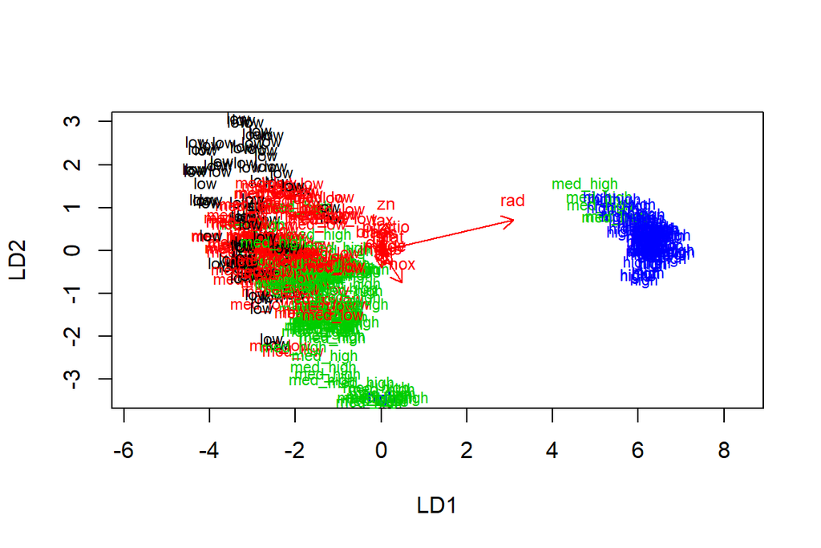

```r
library(MASS)
# Fit the linear discriminant analysis on the train set
lda.fit <- lda(crime~., data = train)

# the function for lda biplot arrows
lda.arrows <- function(x, myscale = 1, arrow_heads = 0.1, color = "red", tex = 0.75, choices = c(1,2)){
  heads <- coef(x)
  arrows(x0 = 0, y0 = 0,
         x1 = myscale * heads[,choices[1]],
         y1 = myscale * heads[,choices[2]], col=color, length = arrow_heads)
  text(myscale * heads[,choices], labels = row.names(heads),
       cex = tex, col=color, pos=3)
}

# target classes as numeric
classes <- as.numeric(train$crime)

# Draw the LDA (bi)plot
plot(lda.fit, dimen = 2,col=classes,pch=classes)
lda.arrows(lda.fit, myscale = 1)
```

```r
# save the correct classes from test data
correct_classes <- test$crime

# remove the crime variable from test data
test <- dplyr::select(test, -crime)
# predict classes with test data
lda.pred <- predict(lda.fit, newdata = test)

# cross tabulate the results
table(correct = correct_classes, predicted = lda.pred$class)
```

```
##           predicted
## correct    low med_low med_high high
##   low       13      10        0    0
##   med_low    5      13        6    0
##   med_high   0      12       13    1
##   high       0       0        0   29
```

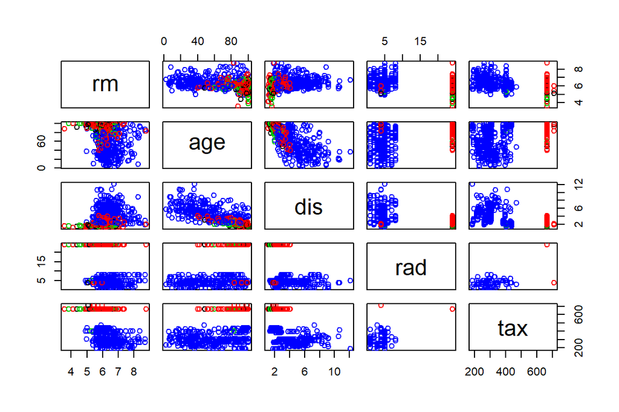

```r
#Reload the Boston dataset and standardize the dataset
data("Boston")
scaled_data <- scale(Boston)
#calculate euclidian distance
dist_man <- dist(Boston)
#Run k-means algorithm on the dataset
km4 <-kmeans(Boston, center=4)
km3 <-kmeans(Boston, center=3)
km2 <-kmeans(Boston, center=2)
# plot the Boston dataset with clusters
pairs(Boston[6:10], col = km4$cluster)
```

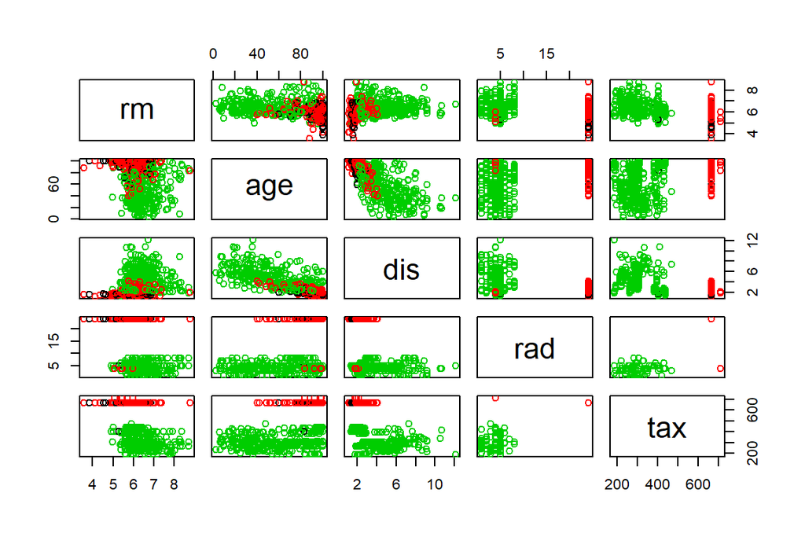

```r
pairs(Boston[6:10], col = km3$cluster)
```

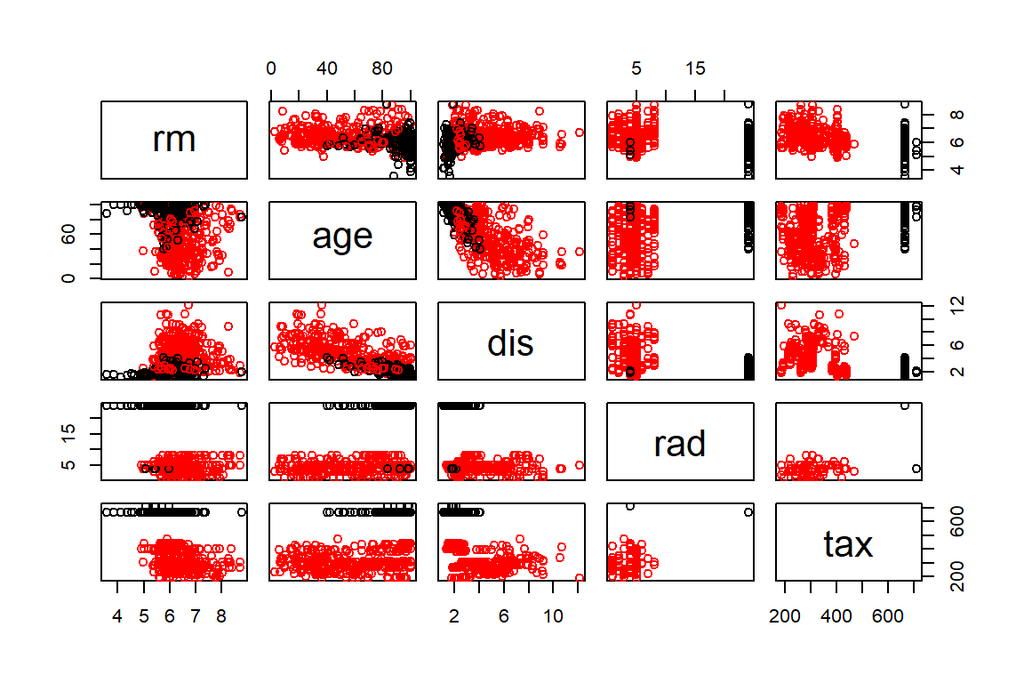

```r
pairs(Boston[6:10], col = km2$cluster)
```

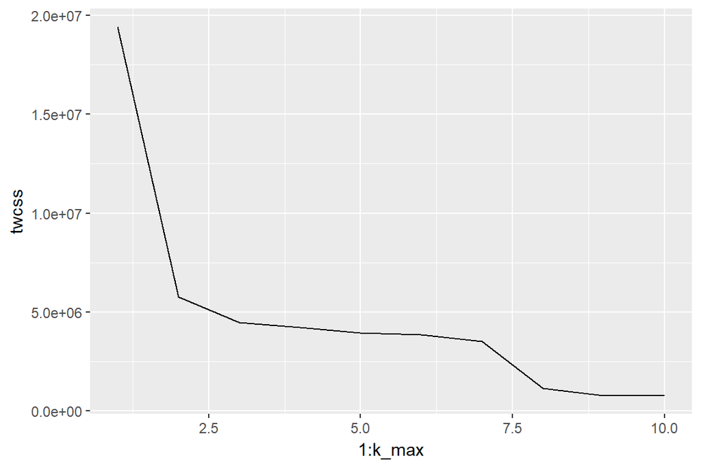

```r
#Investigate optimal number of clusters
k_max <- 10

# calculate the total within sum of squares
twcss <- sapply(1:k_max, function(k){kmeans(Boston, k)$tot.withinss})

# visualize the results
qplot(x = 1:k_max, y = twcss, geom = 'line')
```

[figure not shown]

```r
# determine the k-means clustering and run the model again
km <-kmeans(Boston, centers = 2)

#plot the Boston dataset with clusters
pairs(Boston, col = km$cluster)
```

As we can see from the pairs plot, three and four clusters show significant overlap between clusters. Thus to determine the optimal number of clusters, let’s use twcss. Plots of testing using the cluters sums of squares with in each cluster(twcss) shows(with maximum number of clusters to be 10) there are two distinct clusters. The sharp change in the twcss line graphs occurs at the second cluster from very high to low. The final results of the pairs plot with two clusters(red and black) now shows very clear separation with minimal overlap compared to the previous cluster(4 and 3).

Bonus

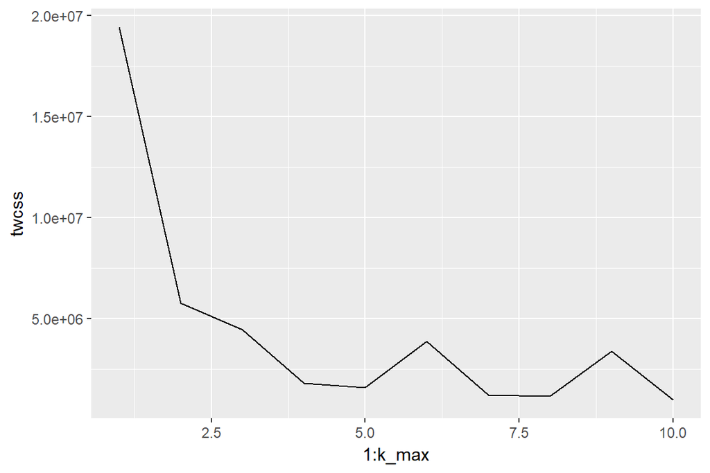

```r
library(MASS)
#standardize the original data
scaled_bos <- scale(Boston)
# select number of clusters
k_max <- 10
# calculate the total within sum of squares
twcss <- sapply(1:k_max, function(k){kmeans(Boston, k)$tot.withinss})

# visualize the results
qplot(x = 1:k_max, y = twcss, geom = 'line')
```

[figure not shown]

```r
#Based on the twcss, select reasonalbe number of cluster
kma <-kmeans(Boston, center=3)
pairs(Boston, col = kma$cluster)
```

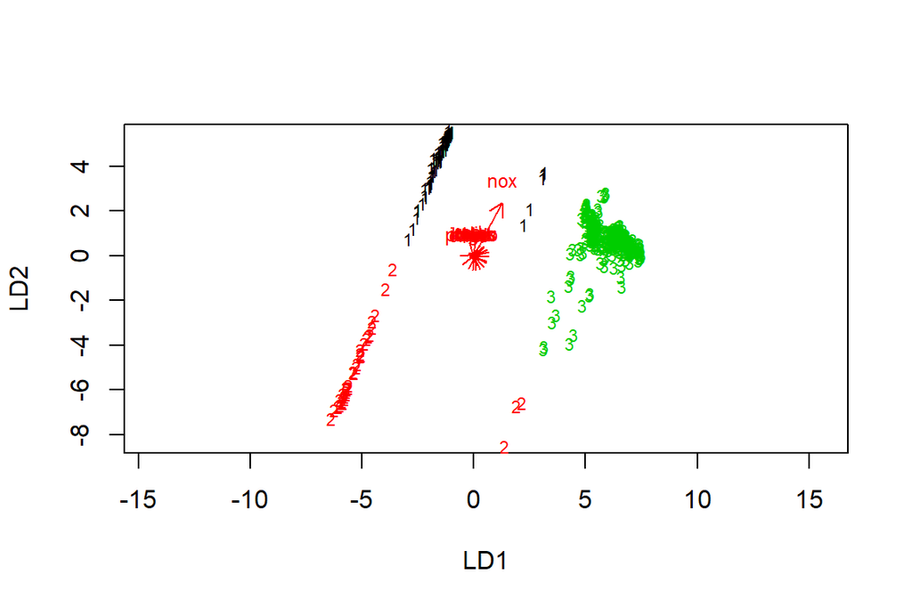

```r
#perform LDA using the clusters as target classes
lda.fit <- lda(kma$cluster~., data = Boston)
#Visualize the results with a biplot

lda.arrows <- function(x, myscale = 1, arrow_heads = 0.1, color = "red", tex = 0.75, choices = c(1,2)){
  heads <- coef(x)
  arrows(x0 = 0, y0 = 0,
         x1 = myscale * heads[,choices[1]],
         y1 = myscale * heads[,choices[2]], col=color, length = arrow_heads)
  text(myscale * heads[,choices], labels = row.names(heads),
       cex = tex, col=color, pos=3)
}

# target classes as numeric
classes <- as.numeric(kma$cluster)

# Draw the LDA (bi)plot
plot(lda.fit, dimen = 2,col=classes,pch=classes)
lda.arrows(lda.fit, myscale = 1)
```

# Chapter 5: Dimentionality Reduction

*Read data from local folder*

```r
human <-read.table("D:/GitHub/IODS-project/human.csv", sep = ";", header = TRUE)
str(human)
```

```
## 'data.frame':    155 obs. of  8 variables:
##  $ Edu2.FM  : num  1.007 0.997 0.983 0.989 0.969 ...
##  $ Labo.FM  : num  0.891 0.819 0.825 0.884 0.829 ...
##  $ Edu.Exp  : num  17.5 20.2 15.8 18.7 17.9 16.5 18.6 16.5 15.9 19.2 ...
##  $ Life.Exp : num  81.6 82.4 83 80.2 81.6 80.9 80.9 79.1 82 81.8 ...
##  $ GNI      : int  64992 42261 56431 44025 45435 43919 39568 52947 42155 32689 ...
##  $ Mat.Mor  : int  4 6 6 5 6 7 9 28 11 8 ...
##  $ Ado.Birth: num  7.8 12.1 1.9 5.1 6.2 3.8 8.2 31 14.5 25.3 ...
##  $ Parli.F  : num  39.6 30.5 28.5 38 36.9 36.9 19.9 19.4 28.2 31.4 ...
```

```r
dim(human)
```

```
## [1] 155   8
```

*The data contains information about human development index from most countreis in the world. In this dataset, a total of 8 variables(indicators) and 155 observations are included. Description of the variabels(which are related to health and knowledge, and empowerment) are given below*

*“GNI” = Gross National Income per capita*

*#“Life.Exp” = Life expectancy at birth*

*#“Edu.Exp” = Expected years of schooling*

*#“Mat.Mor” = Maternal mortality ratio*

*#“Ado.Birth” = Adolescent birth rate*

*#“Parli.F” = Percetange of female representatives in parliament*

*#“Edu2.F” = Proportion of females with at least secondary education*

*#“Edu2.M” = Proportion of males with at least secondary education*

*#“Labo2.F” = Proportion of females in the labour force*

*#“Labo2.M” " Proportion of males in the labour force*

*#“Edu2.FM” = Edu2.F/Edu2.M*

*#“Labo.FM” = Labo2.F/Labo2.M*

*Show a graphical overview of the data and summary*

```r
library(GGally)
```

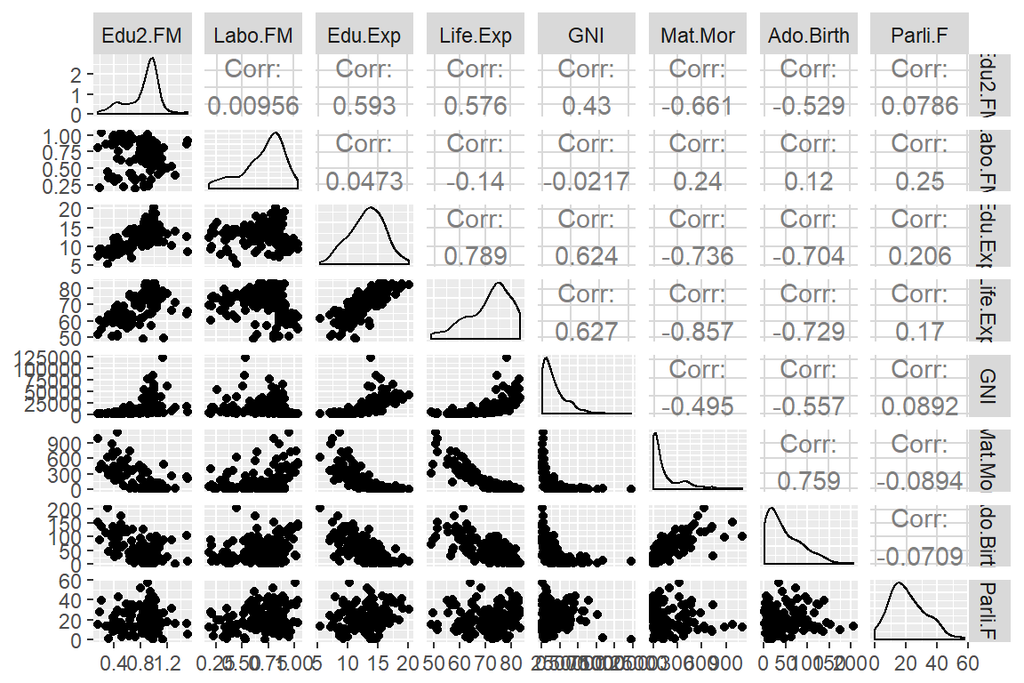

```r
library(dplyr)
library(corrplot)

ggpairs(human)
```

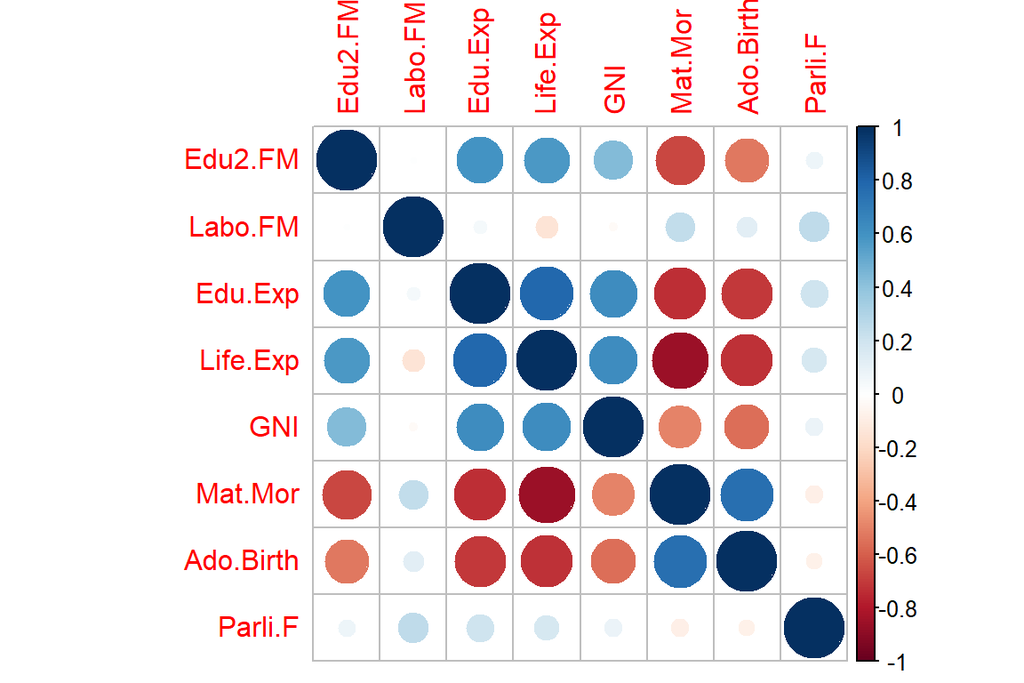

```r
cor(human)%>% corrplot()
```

```r
summary(human)
```

```
##     Edu2.FM          Labo.FM          Edu.Exp         Life.Exp
##  Min.   :0.1717   Min.   :0.1857   Min.   : 5.40   Min.   :49.00
##  1st Qu.:0.7264   1st Qu.:0.5984   1st Qu.:11.25   1st Qu.:66.30
##  Median :0.9375   Median :0.7535   Median :13.50   Median :74.20
##  Mean   :0.8529   Mean   :0.7074   Mean   :13.18   Mean   :71.65
##  3rd Qu.:0.9968   3rd Qu.:0.8535   3rd Qu.:15.20   3rd Qu.:77.25
##  Max.   :1.4967   Max.   :1.0380   Max.   :20.20   Max.   :83.50
##       GNI            Mat.Mor         Ado.Birth         Parli.F
##  Min.   :   581   Min.   :   1.0   Min.   :  0.60   Min.   : 0.00
##  1st Qu.:  4198   1st Qu.:  11.5   1st Qu.: 12.65   1st Qu.:12.40
##  Median : 12040   Median :  49.0   Median : 33.60   Median :19.30
##  Mean   : 17628   Mean   : 149.1   Mean   : 47.16   Mean   :20.91
##  3rd Qu.: 24512   3rd Qu.: 190.0   3rd Qu.: 71.95   3rd Qu.:27.95
##  Max.   :123124   Max.   :1100.0   Max.   :204.80   Max.   :57.50
```

*The data distibutions shows the minimum, median, mean, max, 1st and 2nd quantiles. In some countries it shows forexample no representation of female in the parliament(Minmum zero) and big difference in GNI (Max=123124, Min=581). The correlation plot, on the otherhand, shows both negative and postive correlations between variables(e.g. “Edu2.FM” and Mat.Mor shows negative correlation while Mat.Mor and Ado.Birth indicates postitive correlation)*

*Perform principal component analysis (PCA)*

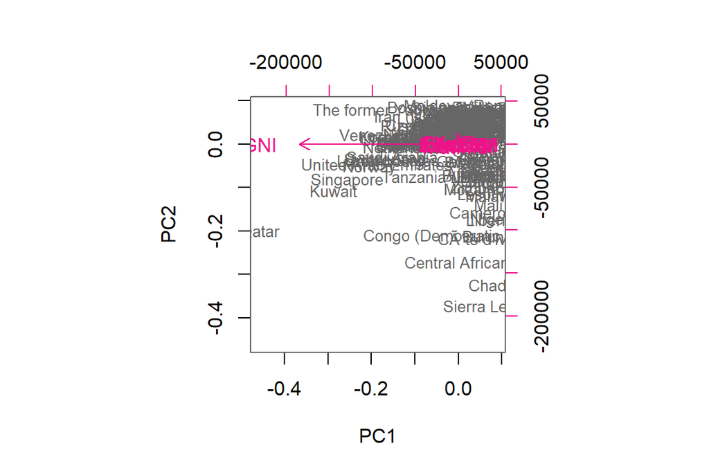

```r
library(dplyr)
library(GGally)
library(MASS)

# perform principal component analysis (with the SVD method)
pca_human <- prcomp(human)

# draw a biplot of the principal component representation and the original variables

biplot(pca_human, choices = 1:2,cex=c(0.8,1),col=c("grey40", "deeppink2"))
```

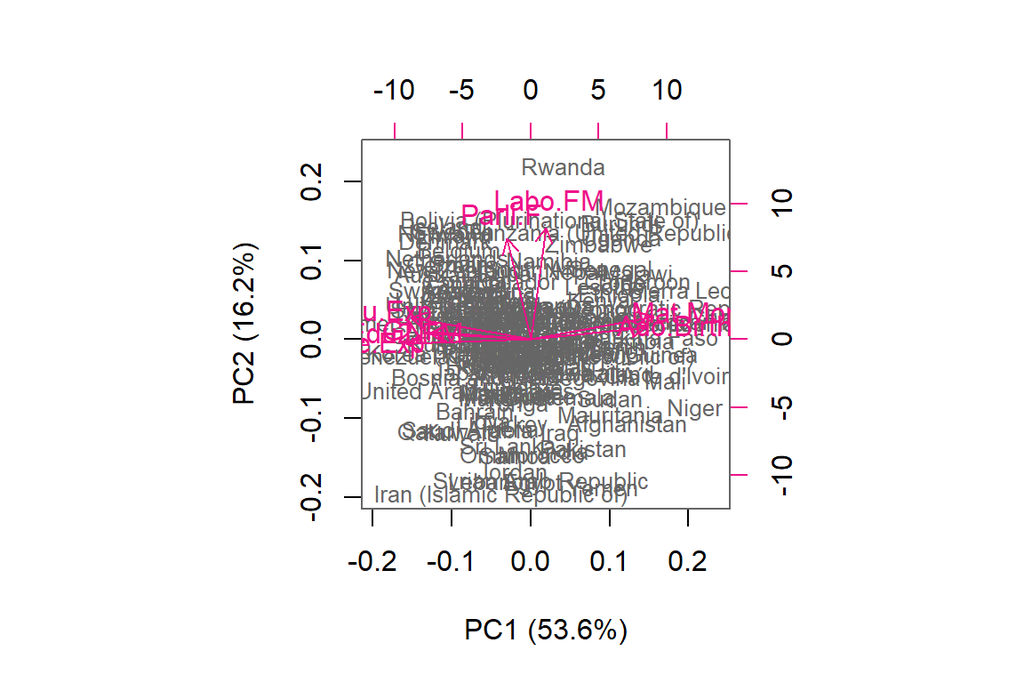

```r
#standardize the variables and repeat the analysis

human_std <- scale(human)


pca_human <- prcomp(human_std)
s <- summary(pca_human)
pca_pr <- round(100*s$importance[2, ], digits = 1)

# create object pc_lab to be used as axis labels
pc_lab <- paste0(names(pca_pr), " (", pca_pr, "%)")

# draw a biplot
biplot(pca_human, cex = c(0.8, 1), col = c("grey40", "deeppink2"), xlab = pc_lab[1], ylab = pc_lab[2])
```

*after standrdization the mean value for all variables became zero. And all values to the left and right of the mean have negative and positive respectively. since the pricipal compoents are sensitive to the realtive scaling of variables with large variance(e.g the GNU data(Max=123124, Min=581), it assumes that those with big variance are more important than others. As a result, GNU values are more important than others before standardization. The angle between arrows shows how much they are correlated, the smaller the angle the stronger the correlation is. Forexample, maternal mortality and adolescent birth rate are very close to eaachother, meaning they are correlated. Also, the direction of the arrows shows to which PC-axis they are more important(e.g,Percetange of female representatives in parliament and the proportion of female to male in the labor force are correlated to eachother and are parallel to the PC2 unlike the others). The lenghth of the arrows shows the standard deviations from the mean value*

```r
library(FactoMineR)
library(ggplot2)
library(dplyr)
library(tidyr)

data(tea)
keep_columns <- c("Tea", "evening", "price", "tearoom", "where", "sugar")
tea_time <-dplyr::select(tea, one_of(keep_columns))

# look at the summaries and structure of the data
summary(tea_time)
```

```
##         Tea             evening                price            tearoom
##  black    : 74   evening    :103   p_branded      : 95   Not.tearoom:242
##  Earl Grey:193   Not.evening:197   p_cheap        :  7   tearoom    : 58
##  green    : 33                     p_private label: 21
##                                    p_unknown      : 12
##                                    p_upscale      : 53
##                                    p_variable     :112
##                   where          sugar
##  chain store         :192   No.sugar:155
##  chain store+tea shop: 78   sugar   :145
##  tea shop            : 30
##
##
##
```

```r
str(tea_time)
```

```
## 'data.frame':    300 obs. of  6 variables:
##  $ Tea    : Factor w/ 3 levels "black","Earl Grey",..: 1 1 2 2 2 2 2 1 2 1 ...
##  $ evening: Factor w/ 2 levels "evening","Not.evening": 2 2 1 2 1 2 2 1 2 1 ...
##  $ price  : Factor w/ 6 levels "p_branded","p_cheap",..: 4 6 6 6 6 3 6 6 5 5 ...
##  $ tearoom: Factor w/ 2 levels "Not.tearoom",..: 1 1 1 1 1 1 1 1 1 2 ...
##  $ where  : Factor w/ 3 levels "chain store",..: 1 1 1 1 1 1 1 1 2 2 ...
##  $ sugar  : Factor w/ 2 levels "No.sugar","sugar": 2 1 1 2 1 1 1 1 1 1 ...
```

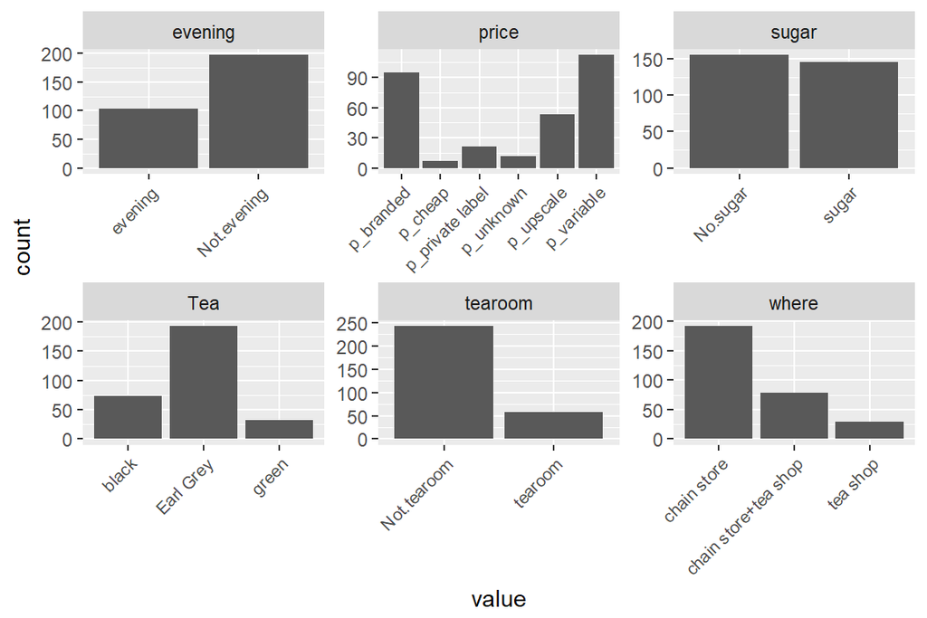

```r
# visualize the dataset
gather(tea_time) %>% ggplot(aes(value)) + facet_wrap("key", scales = "free")+ geom_bar() +theme(axis.text.x = element_text(angle = 45, hjust = 1, size = 8))
```

```r
mca <- MCA(tea_time, graph = FALSE)

# summary of the model

summary(mca)
```

```
##
## Call:
## MCA(X = tea_time, graph = FALSE)
##
##
## Eigenvalues
##                        Dim.1   Dim.2   Dim.3   Dim.4   Dim.5   Dim.6
## Variance               0.296   0.248   0.196   0.189   0.173   0.167
## % of var.             14.778  12.394   9.812   9.460   8.666   8.328
## Cumulative % of var.  14.778  27.173  36.985  46.445  55.110  63.438
##                        Dim.7   Dim.8   Dim.9  Dim.10  Dim.11  Dim.12
## Variance               0.160   0.146   0.131   0.116   0.107   0.072
## % of var.              7.985   7.279   6.541   5.822   5.327   3.607
## Cumulative % of var.  71.423  78.702  85.244  91.066  96.393 100.000
##
## Individuals (the 10 first)
##                    Dim.1    ctr   cos2    Dim.2    ctr   cos2    Dim.3
## 1               | -0.443  0.221  0.040 |  0.182  0.045  0.007 |  0.239
## 2               |  0.051  0.003  0.002 |  0.046  0.003  0.002 | -0.779
## 3               | -0.128  0.019  0.017 | -0.358  0.172  0.131 | -0.015
## 4               | -0.357  0.143  0.165 | -0.282  0.107  0.103 |  0.157
## 5               | -0.128  0.019  0.017 | -0.358  0.172  0.131 | -0.015
## 6               | -0.462  0.240  0.079 |  0.184  0.045  0.013 | -0.510
## 7               | -0.153  0.026  0.031 | -0.179  0.043  0.043 | -0.339
## 8               |  0.076  0.007  0.004 | -0.133  0.024  0.013 | -0.455
## 9               |  0.649  0.475  0.259 |  0.060  0.005  0.002 | -0.046
## 10              |  1.319  1.962  0.594 | -0.191  0.049  0.012 | -0.190
##                    ctr   cos2
## 1                0.097  0.012 |
## 2                1.031  0.521 |
## 3                0.000  0.000 |
## 4                0.042  0.032 |
## 5                0.000  0.000 |
## 6                0.442  0.097 |
## 7                0.196  0.154 |
## 8                0.351  0.148 |
## 9                0.004  0.001 |
## 10               0.061  0.012 |
##
## Categories (the 10 first)
```

[output cut: 16 more lines]

```
## Not.evening      4.394 | -0.296  4.892  0.168 -7.083 |
## p_branded        3.740 | -0.092  0.230  0.004 -1.088 |
## p_cheap         -0.149 | -0.583  0.674  0.008 -1.559 |
## p_private label  1.501 | -0.626  2.330  0.030 -2.970 |
## p_unknown       -0.181 |  1.214  5.006  0.061  4.285 |
## p_upscale        7.553 |  0.580  5.053  0.072  4.649 |
##
## Categorical variables (eta2)
##                   Dim.1 Dim.2 Dim.3
## Tea             | 0.080 0.353 0.244 |
## evening         | 0.001 0.065 0.168 |
## price           | 0.639 0.415 0.168 |
## tearoom         | 0.322 0.123 0.001 |
## where           | 0.621 0.508 0.163 |
## sugar           | 0.110 0.024 0.434 |
```

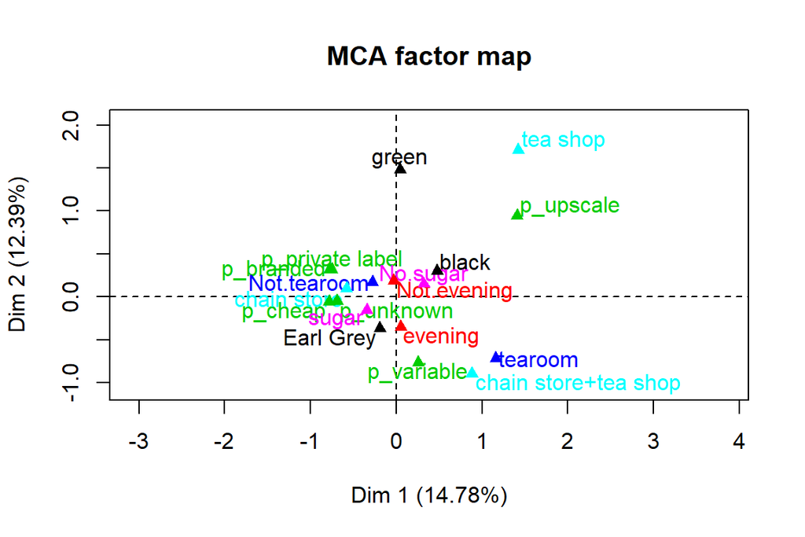

```r
# visualize MCA
plot(mca, invisible=c("ind"), habillage="quali")
```

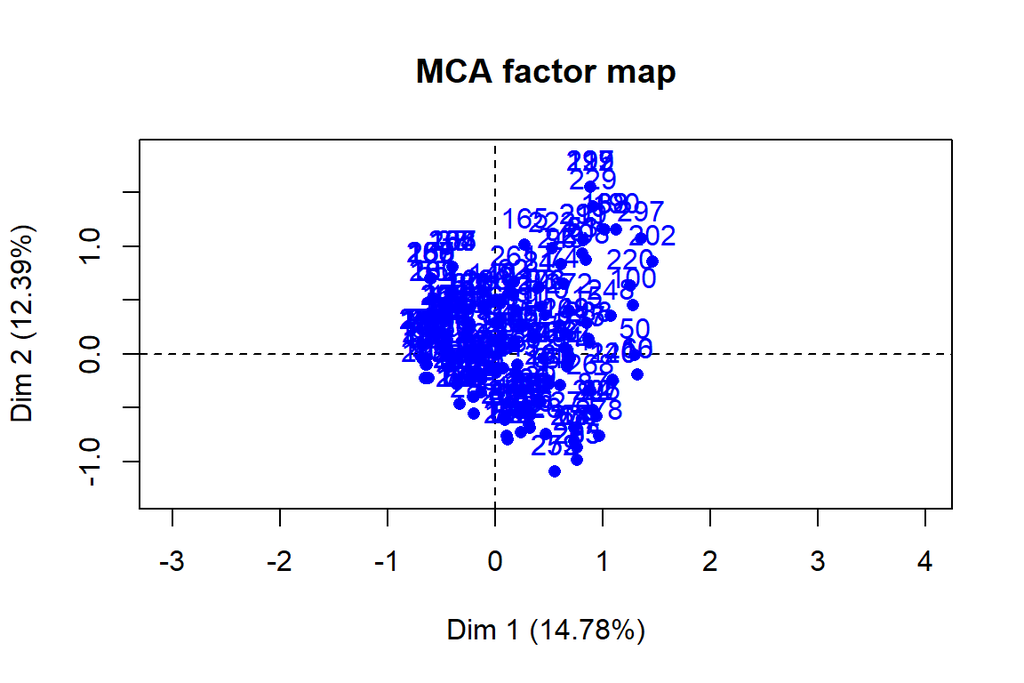

```r
plot(mca, invisible=c("var"), habillage="quali")
```

*summaries of the results of the Multiple Correspondence Analysis shows for all categoris the coordinates of the values, the contribution on the axis and the quality of representation measured by square of the cosine( which follows a gaussian distribution) , the correlation ratio between variable(et2). Thus forexample black tea has coordinate 0.477 on the first axis (dim1), and its contribution is 3.159, and the v.test shows that black tea has large positive value(> 1.96) in the first and second dimension while large negative value(< -1.96) in the third dimension* ***